# `selectLevel`

### Wavelet levels selection procedure

#### Description

```
selectLevel(design, ydata, typeRF = ifelse(is.factor(ydata), "classif", "reg"),
            verbose = TRUE, ntree = 500, ...)
```

#### Arguments

- `design`: The design matrix of a functional variable.
- `ydata`: The outcome data. Must be a factor for classification.
- `typeRF`: The type of forest we want to construct, “classif” for classification or “reg” for regression.
- `verbose`: Should the details be printed.
- `ntree`: The number of trees in the forests (default: 500).
- `...`: optional parameters to be passed to the “varImpGroup” function.

#### Examples

```r
data(toyRegFD)
x <- toyRegFD$FDlist[[1]]
y <- toyRegFD$Y
design <- projectWavelet(xdata=x)
summary(levSel <- selectLevel(design, y, ntree=100, verbose=TRUE))
```

```
## Group names: s7 d7 d6 d5 d4 d3 d2 d1     Nr of variable in each level: 1 1 2 4 8 16 32 64
## normalize = TRUE
## s7 d7 d6 d5 d4 d3 d2 d1
##  1  1  2  4  8 16 32 64
## Regression backward selection.
## Splitting data into a training and a testing set...
## Survival indexes : 1 2 3 4 5 6 7 8 9 10 11 12 13 14 15 16 17 18 19 20 21 22 23 24 25 26 27 28 29 30 31 32 33 34 35 36 37 38 39 40 41 42 43 44 45 46 47 48 49 50 51 52 53 54 55 56 57 58 59 60 61 62 63 64 65 66 67 68 69 70 71 72 73 74 75 76 77 78 79 80 81 82 83 84 85 86 87 88 89 90 91 92 93 94 95 96…
##    d3    d1    d4    s7    d2    d7    d5    d6
## 0.074 0.072 0.065 0.035 0.030 0.008 0.003 0.001
## d6 eliminated. 7 remaining groups of variables.   Error = 1.04
##
##
## Survival indexes : 1 2 5 6 7 8 9 10 11 12 13 14 15 16 17 18 19 20 21 22 23 24 25 26 27 28 29 30 31 32 33 34 35 36 37 38 39 40 41 42 43 44 45 46 47 48 49 50 51 52 53 54 55 56 57 58 59 60 61 62 63 64 65 66 67 68 69 70 71 72 73 74 75 76 77 78 79 80 81 82 83 84 85 86 87 88 89 90 91 92 93 94 95 96 97 …
##     d3     d1     s7     d4     d2     d7     d5
##  0.092  0.073  0.066  0.058  0.032  0.006 -0.001
## d5 eliminated. 6 remaining groups of variables.   Error = 1.02
##
##
## Survival indexes : 1 2 9 10 11 12 13 14 15 16 17 18 19 20 21 22 23 24 25 26 27 28 29 30 31 32 33 34 35 36 37 38 39 40 41 42 43 44 45 46 47 48 49 50 51 52 53 54 55 56 57 58 59 60 61 62 63 64 65 66 67 68 69 70 71 72 73 74 75 76 77 78 79 80 81 82 83 84 85 86 87 88 89 90 91 92 93 94 95 96 97 98 99 10…
##    d3    d1    s7    d4    d2    d7
## 0.085 0.075 0.065 0.057 0.041 0.014
## d7 eliminated. 5 remaining groups of variables.   Error = 0.96
##
##
## Survival indexes : 1 9 10 11 12 13 14 15 16 17 18 19 20 21 22 23 24 25 26 27 28 29 30 31 32 33 34 35 36 37 38 39 40 41 42 43 44 45 46 47 48 49 50 51 52 53 54 55 56 57 58 59 60 61 62 63 64 65 66 67 68 69 70 71 72 73 74 75 76 77 78 79 80 81 82 83 84 85 86 87 88 89 90 91 92 93 94 95 96 97 98 99 100 …
##    d1    d3    d4    d2    s7
## 0.076 0.072 0.053 0.044 0.016
## s7 eliminated. 4 remaining groups of variables.   Error = 1.01
##
##
## Survival indexes : 9 10 11 12 13 14 15 16 17 18 19 20 21 22 23 24 25 26 27 28 29 30 31 32 33 34 35 36 37 38 39 40 41 42 43 44 45 46 47 48 49 50 51 52 53 54 55 56 57 58 59 60 61 62 63 64 65 66 67 68 69 70 71 72 73 74 75 76 77 78 79 80 81 82 83 84 85 86 87 88 89 90 91 92 93 94 95 96 97 98 99 100 10…
##    d3    d1    d4    d2
## 0.092 0.067 0.064 0.031
## d2 eliminated. 3 remaining groups of variables.   Error = 1
##
##
## Survival indexes : 9 10 11 12 13 14 15 16 17 18 19 20 21 22 23 24 25 26 27 28 29 30 31 32 65 66 67 68 69 70 71 72 73 74 75 76 77 78 79 80 81 82 83 84 85 86 87 88 89 90 91 92 93 94 95 96 97 98 99 100 101 102 103 104 105 106 107 108 109 110 111 112 113 114 115 116 117 118 119 120 121 122 123 124 12…
##    d1    d3    d4
## 0.099 0.093 0.080
## d4 eliminated. 2 remaining groups of variables.   Error = 1.02
```

[output cut: 14 more lines]

```
##  d3 d1 d4 d2 s7 d7
##
##
##
##  ---                  ---
##  ---     Summary functional RFE   ---
##  ---                  ---
##
##
## Number of selected variables using a validation set: 6
##
## Selected variables:
## d3 d1 d4 d2 s7 d7
##
## Validation error for the best model: 0.958
```

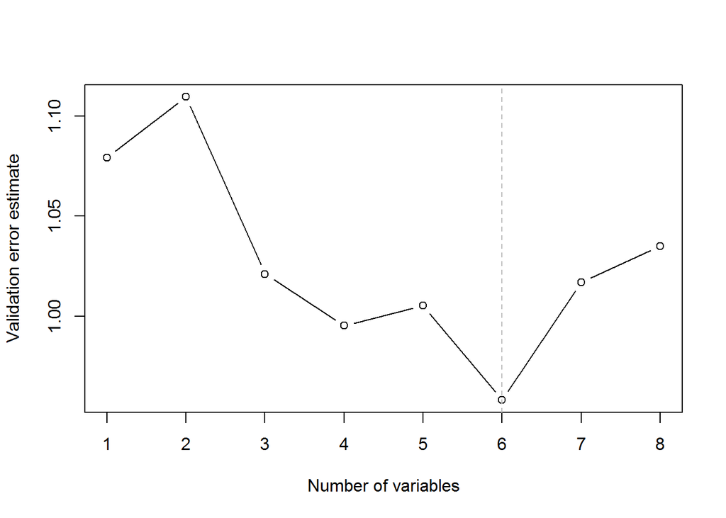

```r
plot(levSel)
```

#### Value

An object of class fRFE which is a list with the following components:

- `nselected`: The number of selected wavelet levels.
- `selection`: The selected wavelet levels.
- `selectionIndexes`: The indexes of selected wavelet levels in the input matrix design.
- `error`: The prediction error computed in each iteration of the backward procedure.
- `typeRF`: The type of the forests, classification or regression.
- `ranking`: The final ranking of the wavelet levels.
- `rankingIndexes`: The final ranking indexes of the wavelet levels.

#### Author(s)

Baptiste Gregorutti

#### References

Gregorutti, B., Michel, B. and Saint Pierre, P. (2015). Grouped variable importance with random forests and application to multiple functional data analysis, Computational Statistics and Data Analysis 90, 15-35. See Also selectGroup,selectFunctional,varImpGroup